# RPKM

```r
library(stringr)
library(reshape2)
library(readr)
library(dplyr)
library(patchwork)
library(ggplot2)
library(knitr)
```

Import CARD data aro index:

```r
aro_index <- read_delim("PRJNA307231/aro_index.tsv",
    "\t", escape_double = FALSE, trim_ws = TRUE)

dim(aro_index)
```

```
## [1] 3326   11
```

```r
length(unique(aro_index$`ARO Accession`))
```

```
## [1] 3323
```

```r
y<-colsplit(aro_index$`ARO Accession`, ":", c("X", "ARO Number"))
aro_index<-cbind(aro_index, select(y, `ARO Number`))
```

# Calculate RPKM

## RGI

```r
library(readr)
RGI_data <- read_delim("data_testing/RGI_analysis/argannot-150bp-10000-reads.fastq_RGI_output.allele_mapping_data.txt", "\t", escape_double = FALSE, trim_ws = TRUE)
kable(head(RGI_data))
```

| Reference Sequence | ARO Term | ARO Accession | Reference Model Type | Reference DB | Reference Allele Source | Resistomes & Variants: Observed in Genome(s) | Resistomes & Variants: Observed in Plasmid(s) | Resistomes & Variants: Observed Pathogen(s) | Completely Mapped Reads | Mapped Reads with Flanking Sequence | All Mapped Reads | Percent Coverage | Length Coverage (bp) | Average MAPQ (Completely Mapped Reads) | Mate Pair Linkage | Reference Length | AMR Gene Family | Drug Class | Resistance Mechanism |
| --- | --- | --- | --- | --- | --- | --- | --- | --- | --- | --- | --- | --- | --- | --- | --- | --- | --- | --- | --- |
| ARO:3001109\|ID:4\|Name:SHV-52\|NCBI:HQ845196 | SHV-52 | 3001109 | protein homolog model | CARD | CARD curation | no data | no data | Klebsiella pneumoniae | 5 | 0 | 5 | 60.98 | 525 | 1 | * | 861 | SHV beta-lactamase | carbapenem; cephalosporin; penam | antibiotic inactivation |
| ARO:3001989\|ID:7\|Name:CTX-M-130\|NCBI:JX017365 | CTX-M-130 | 3001989 | protein homolog model | CARD | CARD curation | no data | no data | Escherichia coli | 2 | 0 | 2 | 34.25 | 300 | 1 | * | 876 | CTX-M beta-lactamase | cephalosporin | antibiotic inactivation |
| ARO:3002356\|ID:8\|Name:NDM-6\|NCBI:JN967644 | NDM-6 | 3002356 | protein homolog model | CARD | CARD curation | no data | no data | Escherichia coli | 4 | 0 | 4 | 57.69 | 469 | 1 | * | 813 | NDM beta-lactamase | carbapenem; cephalosporin; cephamycin; penam | antibiotic inactivation |
| ARO:3001855\|ID:9\|Name:ACT-35\|NCBI:LC004922 | ACT-35 | 3001855 | protein homolog model | CARD | CARD curation | no data | no data | Enterobacter cloacae | 2 | 0 | 2 | 26.18 | 300 | 1 | * | 1146 | ACT beta-lactamase | carbapenem; cephalosporin; cephamycin; penam | antibiotic inactivation |
| ARO:3002244\|ID:10\|Name:CARB-5\|NCBI:AF135373 | CARB-5 | 3002244 | protein homolog model | CARD | CARD curation | no data | no data | Acinetobacter calcoaceticus | 4 | 0 | 4 | 58.86 | 528 | 1 | * | 897 | CARB beta-lactamase | penam | antibiotic inactivation |
| ARO:3000600\|ID:11\|Name:Erm(34)\|NCBI:AY234334 | Erm(34) | 3000600 | protein homolog model | CARD | CARD curation | no data | no data | Bacillus clausii | 6 | 0 | 6 | 58.75 | 497 | 44 | * | 846 | Erm 23S ribosomal RNA methyltransferase | macrolide antibiotic; lincosamide antibiotic; streptogramin antibiotic | antibiotic target alteration |

Obtain AMR gene family from CARD database:

```r
RGI_data<-merge(
select(RGI_data, -`AMR Gene Family`, -`Drug Class`, -`Resistance Mechanism`),
select(aro_index,`Model Sequence ID`, `AMR Gene Family`,`Drug Class`, `Resistance Mechanism`,`Protein Accession`,`ARO Number`, `ARO Name` ), by.x = "ARO Accession", by.y="ARO Number", all.x = TRUE)
```

```r
table(is.na(RGI_data$`AMR Gene Family`))
```

```
##
## FALSE
##  2019
```

Calculate RPKM:

```r
library(dplyr)
totalNumReads<- 10000
RGI_data<-RGI_data%>%mutate(RPKM=`All Mapped Reads` /(`Reference Length`/1000 * totalNumReads/1000000))
```

### Average MAPQ distribution

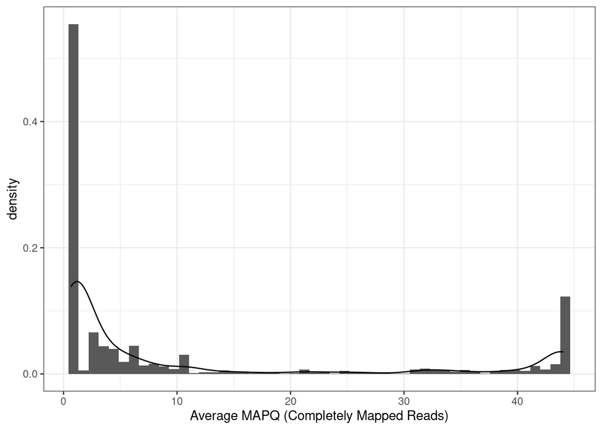

```r
library(ggplot2)
ggplot(RGI_data, aes(`Average MAPQ (Completely Mapped Reads)`)) +
  geom_histogram(bins=50, aes(y = stat(density)))+geom_density()+theme_bw()
```

### Apply Average MAPQ filter:

```r
RGI_data<-RGI_data%>%filter(`Average MAPQ (Completely Mapped Reads)`>10)
```

### RPKM sum per AMR gene family

```r
library(knitr)
n_distinct(RGI_data$`AMR Gene Family`)
```

```
## [1] 125
```

```r
AMR_family_RGI<-RGI_data%>%
  group_by(`AMR Gene Family`)%>%
  summarise('number of AMR genes per family (RGI)'=n(),
            sum_RPKM_RGI=sum(RPKM),
            avg_MAPQ=mean(`Average MAPQ (Completely Mapped Reads)`),
            q1_MAPQ=quantile(`Average MAPQ (Completely Mapped Reads)`, 0.25),
            p3_MAPQ=quantile(`Average MAPQ (Completely Mapped Reads)`,0.75),)%>%arrange(desc(sum_RPKM_RGI))
kable(head(AMR_family_RGI))
```

| AMR Gene Family | number of AMR genes per family (RGI) | sum_RPKM_RGI | avg_MAPQ | q1_MAPQ | p3_MAPQ |
| --- | --- | --- | --- | --- | --- |
| trimethoprim resistant dihydrofolate reductase dfr | 35 | 22523.60 | 35.09714 | 31.00 | 44 |
| major facilitator superfamily (MFS) antibiotic efflux pump | 36 | 22513.83 | 41.25917 | 44.00 | 44 |
| OXA beta-lactamase | 41 | 21847.96 | 25.99024 | 11.00 | 35 |
| Erm 23S ribosomal RNA methyltransferase | 29 | 19076.80 | 42.06690 | 41.71 | 44 |
| AAC(6’) | 26 | 16687.01 | 36.13154 | 32.68 | 44 |
| chloramphenicol acetyltransferase (CAT) | 21 | 15610.47 | 36.57667 | 31.25 | 44 |

# ARIBA

```r
Ariba_data <- read_delim("data_testing/ariba_analysis/argannot-150bp-10000-reads_ariba_results/report.tsv",
    "\t", escape_double = FALSE, trim_ws = TRUE)
```

Remove contig and variant data, select only coding sequences

```r
Ariba_data<-Ariba_data %>% filter(gene==1)%>%select(c(1:8,31))%>%unique()
```

Calculate RPKM:

```r
Ariba_data<-Ariba_data%>%mutate(RPKM=reads /(ref_len/1000 * totalNumReads/1000000))
kable(head(Ariba_data))
```

| #ariba_ref_name | ref_name | gene | var_only | flag | reads | cluster | ref_len | free_text | RPKM |
| --- | --- | --- | --- | --- | --- | --- | --- | --- | --- |
| AAC_2___Ic.3002525.AL123456.3.314308_314854.4719 | AAC_2___Ic.3002525.AL123456.3.314308_314854.4719 | 1 | 0 | 16 | 12 | AAC_2___Ic | 546 | b“AAC(2’)-Ic is a chromosomal-encoded aminoglycoside acetyltransferase in M. tuberculosis and Mycobacterium tuberculosis variant bovis”;AAC(2’)-Ic | 2197.802 |
| AAC_2___Ie.3002527.AL583926.1.40191_40740.5510 | AAC_2___Ie.3002527.AL583926.1.40191_40740.5510 | 1 | 0 | 16 | 12 | AAC_2___Ie | 549 | b“AAC(2’)-Ie is a chromosomal-encoded aminoglycoside acetyltransferase in M. leprae”;AAC(2’)-Ie | 2185.792 |
| AAC_3__IIb.3002534.M97172.655_1465.10 | AAC_3__IIb.3002534.M97172.655_1465.10 | 1 | 0 | 16 | 20 | AAC_3__IIb | 810 | AAC(3)-IIb;b’AAC(3)-IIb is an aminoglycoside acetyltransferase in E. coli, A. faecalis and S. marcescens’ | 2469.136 |
| AAC_3__IIe.3004621.EU022315.1.0_861.5340 | AAC_3__IIe.3004621.EU022315.1.0_861.5340 | 1 | 0 | 16 | 50 | AAC_3__II- | 861 | b’AAC(3)-IIe is a plasmid-encoded aminoglycoside acetyltransferase in E. coli’;AAC(3)-IIe | 5807.201 |
| AAC_3__IV.3002539.DQ241380.1.0_777.3715 | AAC_3__IV.3002539.DQ241380.1.0_777.3715 | 1 | 0 | 16 | 16 | AAC_3__IV | 777 | b’AAC(3)-IV is a plasmid-encoded aminoglycoside acetyltransferase in E. coli, C. jejuni and P. stutzeri’;AAC(3)-IV | 2059.202 |
| AAC_3__VIIIa.3002542.M55426.465_1326.12 | AAC_3__VIIIa.3002542.M55426.465_1326.12 | 1 | 0 | 528 | 14 | AAC_3__VIIIa | 861 | b’AAC(3)-VIIIa is a chromosomal-encoded aminoglycoside acetyltransferase in Streptomyces fradiae’;AAC(3)-VIIIa | 1626.016 |

### Obtain AMR gene family

Trasform ARIBA notation to merge with CARD DB

```r
library(stringr)
library(reshape2)
y<-colsplit(Ariba_data$ref_name, "\\.", c("ARO Term", "ARO Accession","NCBI","init_final","Model Sequence ID","X"))
y$NCBI<-ifelse(str_detect(y$init_final, "_"),y$NCBI ,paste(y$NCBI,".",y$init_final) )
y$init_final<-ifelse(str_detect(y$init_final, "_"), y$init_final, y$`Model Sequence ID`)
y$`Model Sequence ID`<-ifelse(str_detect(y$`Model Sequence ID`, "_"), y$X, y$`Model Sequence ID`)
y$`ARO Accession`<-ifelse(y$`ARO Accession`<3000000, y$NCBI, y$`ARO Accession`)
y$`ARO Accession`<-str_split_fixed(y$`ARO Accession`, "\\.", 2)[ ,1]
y<-select(y, -X)
Ariba_data<-cbind(Ariba_data,y)
Ariba_data$`ARO Accession`<-as.numeric(Ariba_data$`ARO Accession`)

Ariba_data<-merge(Ariba_data, select(aro_index,`Model Sequence ID`, `AMR Gene Family`,`Drug Class`, `Resistance Mechanism`,`Protein Accession`,  `ARO Number`, `ARO Name`) , by.x = "ARO Accession", by.y="ARO Number", all.x = TRUE)
```

### RPKM sum per AMR gene family

```r
library(knitr)
library(dplyr)
AMR_family_ARIBA<-Ariba_data%>%
  group_by(`AMR Gene Family`)%>%
  summarise('number of AMR genes per family(ARIBA)'=n(),
            'sum_RPKM_ariba'=sum(RPKM))%>%arrange(desc('sum_RPKM_ariba'))

kable(head(AMR_family_ARIBA))
```

| AMR Gene Family | number of AMR genes per family(ARIBA) | sum_RPKM_ariba |
| --- | --- | --- |
| 16S rRNA methyltransferase (A1408) | 1 | 1818.182 |
| 16S rRNA methyltransferase (G1405) | 2 | 2797.478 |
| AAC(2’) | 2 | 4383.595 |
| AAC(3) | 5 | 14768.573 |
| AAC(6’) | 6 | 18053.867 |
| AAC(6’);APH(2’’) | 1 | 1666.667 |

# GROOT

Get groot report (uniqseq)

```r
library(readr)
Groot_data <- read_delim("data_testing/groot_analysis/argannot-150bp-10000-reads-uniqseq-0report",
    "\t", escape_double = FALSE, col_names = FALSE,
    trim_ws = TRUE)
names(Groot_data)<-c("AMR.gene", "read.count", "gene.length", "coverage.cigar")
kable(head(Groot_data))
```

| AMR.gene | read.count | gene.length | coverage.cigar |
| --- | --- | --- | --- |
| Bacillus_clausii_chloramphenicol.3004452.AY238971.1.1054-1741.4424 | 4 | 687 | 198D338M151D |
| OXA-474.3003631.KR182167.1.0-810.5731 | 1 | 810 | 538D151M121D |
| TEM-92.3000959.AF143804.0-861.1961 | 4 | 861 | 282D151M142D254M32D |
| OXA-67.3001437.DQ491200.0-825.1936 | 2 | 825 | 7D151M118D151M398D |
| TEM-216.3001393.KF944358.0-861.1494 | 3 | 861 | 447D151M43D201M19D |
| rmtD.3002667.EU269034.2.1479-2223.4675 | 3 | 744 | 45D151M87D151M61D151M98D |

Trasform GROOT notation and merge with CARD DB

```r
library(stringr)
library(reshape2)
library(dplyr)
y<-colsplit(Groot_data$AMR.gene, "\\.", c("ARO Term", "ARO Accession","NCBI","init_final","Model Sequence ID","X"))
y$NCBI<-ifelse(str_detect(y$init_final, "-"),y$NCBI ,paste(y$NCBI,".",y$init_final, sep = "") )
y$init_final<-ifelse(str_detect(y$init_final, "-"), y$init_final, y$`Model Sequence ID`)
y$`Model Sequence ID`<-ifelse(str_detect(y$`Model Sequence ID`, "-"), y$X, y$`Model Sequence ID`)
y$`ARO Accession`<-ifelse(y$`ARO Accession`<3000000, y$NCBI, y$`ARO Accession`)
y$`ARO Accession`<-str_split_fixed(y$`ARO Accession`, "\\.", 2)[ ,1]
y<-select(y, -X)
Groot_data<-cbind(Groot_data,y)
Groot_data$`ARO Accession`<-as.numeric(Groot_data$`ARO Accession`)
Groot_data<-merge(Groot_data, select(aro_index,`Model Sequence ID`, `AMR Gene Family`,`Drug Class`, `Resistance Mechanism`,`Protein Accession`, `ARO Number`, `ARO Name`) ,  by.x = "ARO Accession", by.y="ARO Number", all.x = TRUE)
```

Remove non coding AMR sequences:

```r
Groot_data<-Groot_data%>%filter(!is.na(`Protein Accession`))
```

Calculate RPKM:

```r
Groot_data<-Groot_data%>%mutate(RPKM=read.count /(gene.length/1000 * totalNumReads/1000000))
```

```r
library(knitr)
n_distinct(Groot_data$`AMR Gene Family`)
```

```
## [1] 138
```

```r
AMR_family_Groot<-Groot_data%>%
  group_by(`AMR Gene Family`)%>%
  summarise('number of AMR genes per family (groot)'=n(),
            sum_RPKM_groot=sum(RPKM))%>%arrange(desc(sum_RPKM_groot))
kable(head(AMR_family_Groot))
```

| AMR Gene Family | number of AMR genes per family (groot) | sum_RPKM_groot |
| --- | --- | --- |
| OXA beta-lactamase | 286 | 127376.53 |
| TEM beta-lactamase | 147 | 96640.76 |
| SHV beta-lactamase | 113 | 86700.04 |
| CTX-M beta-lactamase | 125 | 71126.97 |
| CMY beta-lactamase | 103 | 60814.02 |
| quinolone resistance protein (qnr) | 83 | 43595.37 |

# ARIBA vs RGI vs GROOT

Number of AMR Gene Families detected by each pipeline:

```r
length(AMR_family_ARIBA$`AMR Gene Family`)
```

```
## [1] 97
```

```r
length(AMR_family_RGI$`AMR Gene Family`)
```

```
## [1] 125
```

```r
length(AMR_family_Groot$`AMR Gene Family`)
```

```
## [1] 138
```

Merge data obtained from the 3 pipelines:

```r
AMR_family<-merge(AMR_family_ARIBA, AMR_family_RGI[ ,1:3], by="AMR Gene Family", all=TRUE)
AMR_family<-merge(AMR_family, AMR_family_Groot, by="AMR Gene Family", all=TRUE)
```

```r
venntransform<-function(x){
  x$RGI<-ifelse(is.na(x$sum_RPKM_RGI),FALSE,TRUE)
  x$Ariba<-ifelse(is.na(x$sum_RPKM_ariba),FALSE,TRUE)
  x$Groot<-ifelse(is.na(x$sum_RPKM_groot),FALSE,TRUE)
  x$All<-ifelse(x$RGI==TRUE & x$Ariba==TRUE & x$Groot==TRUE, TRUE, FALSE)
  return(x)}

library(ggvenn)
```

```r
vennplot<-function(x){
y<-ggplot(x) + geom_venn(aes(A = RGI, B = Ariba, C = Groot),fill_color = c("chartreuse", "orange", "darkorchid1"), text_size=4, set_name_size = 2, stroke_size = 0.2, show_percentage = FALSE)+theme_void()+coord_fixed()+theme(title=element_text(size=5))
  return(y)}
```

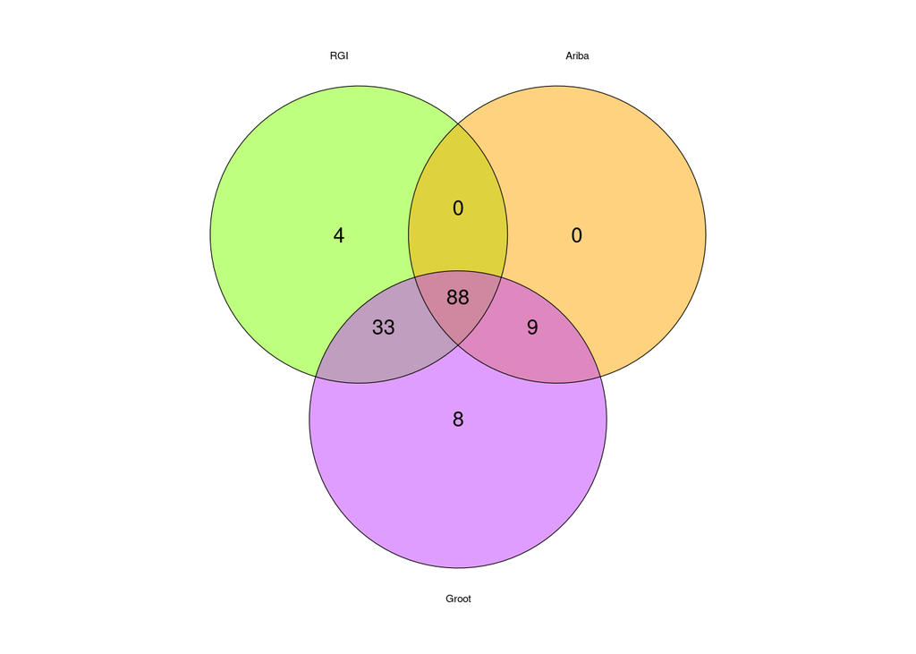

```r
AMR_family_venn<-venntransform(AMR_family)
vennplot(AMR_family_venn)
```

Transform data according to which pipeline has detected each AMR gene family:

```r
data_trans<-function(x){
x$RGI<-ifelse(is.na(x$sum_RPKM_RGI),0,1)
x$Ariba<-ifelse(is.na(x$sum_RPKM_ariba),0,1)
x$Groot<-ifelse(is.na(x$sum_RPKM_groot),0,1)
x$npipelines<-apply(select(x, RGI, Ariba,Groot),1, sum)
x$npipelines<-as.factor(x$npipelines)
x$pipelines<-ifelse(x$npipelines==3, "All",
                                ifelse(x$npipelines==2 & x$RGI==0, "Groot+Ariba",
                                       ifelse(x$npipelines==2 & x$Ariba==0, "RGI+Groot",
                                              ifelse(x$npipelines==2 & x$Groot==0, "RGI+Ariba",
                                                     ifelse(x$RGI==1, "RGI only",
                                                            ifelse(x$Ariba==1, "Ariba only", "Groot only"))))))
x$pipelines_class<-ifelse(x$npipelines==1,0,1)
return(x)}
```

```r
AMR_family<-data_trans(AMR_family)
```

Store discordant families names:

```r
discrodant_families<-list(AMR_family[AMR_family$pipelines=="RGI only" ,1],
AMR_family[AMR_family$pipelines=="Groot only" ,1],
AMR_family[AMR_family$pipelines=="RGI+Groot" ,1],
AMR_family[AMR_family$pipelines=="Groot+Ariba" ,1])
names(discrodant_families)<-c("RGI only", "Groot only", "RGI+Groot", "Groot+Ariba")
```

```r
capture.output(discrodant_families, file = "discrodant_families.txt")
```

RPKM distribution of AMR gene families according to the number of pipelines:

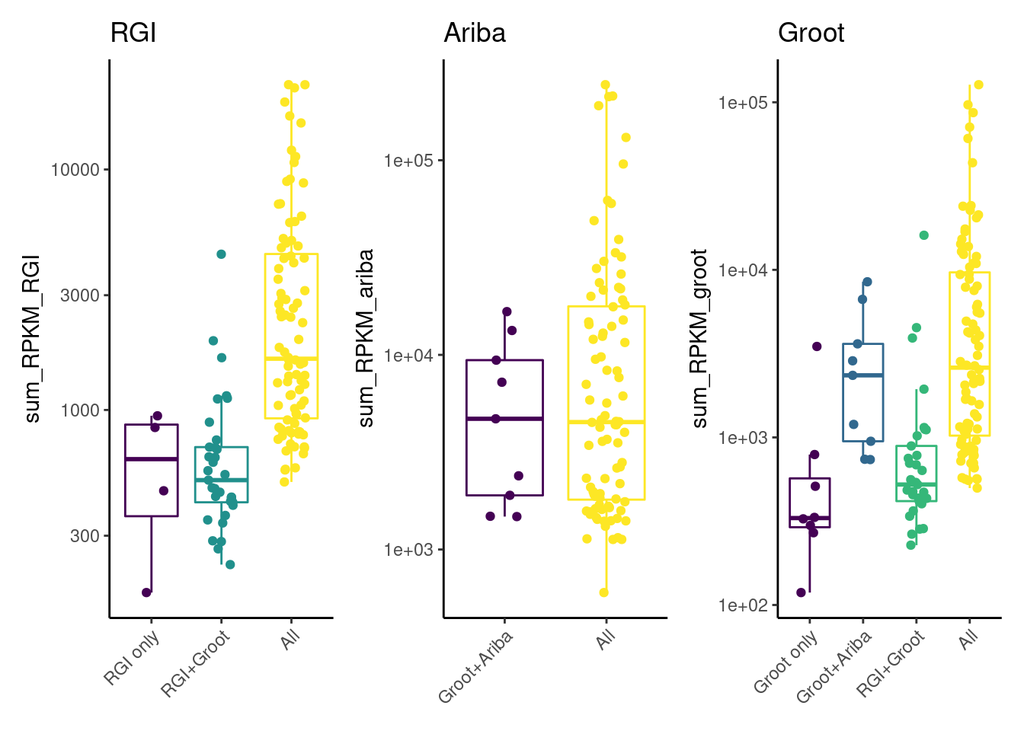

```r
AMR_family$pipelines<-factor(AMR_family$pipelines, ordered = TRUE, levels = c("RGI only", "Ariba only", "Groot only", "Groot+Ariba", "RGI+Groot", "RGI+Ariba", "All"))

p_RGI<-ggplot(subset(AMR_family, AMR_family$RGI==1), aes(pipelines, sum_RPKM_RGI))+geom_boxplot(aes(colour=pipelines), outlier.shape = NA, na.rm = TRUE)+geom_jitter(width = 0.2, aes(colour=pipelines))+theme_classic()+theme(legend.position = "none")+ggtitle("RGI")+scale_y_continuous(trans='log10')+theme(axis.text.x = element_text(angle=45, hjust = 1), axis.title.x = element_blank())

p_Ariba<-ggplot(subset(AMR_family, AMR_family$Ariba==1), aes(pipelines, sum_RPKM_ariba))+geom_boxplot(aes(colour=pipelines), outlier.shape = NA, na.rm = TRUE)+geom_jitter(width = 0.2, aes(colour=pipelines))+theme_classic()+theme(legend.position = "none")+ggtitle("Ariba")+scale_y_continuous(trans='log10')+theme(axis.text.x = element_text(angle=45, hjust=1), axis.title.x = element_blank())

p_Groot<-ggplot(subset(AMR_family, AMR_family$Groot==1), aes(pipelines, sum_RPKM_groot))+geom_boxplot(aes(colour=pipelines), outlier.shape = NA, na.rm = TRUE)+geom_jitter(width = 0.2, aes(colour=pipelines))+theme_classic()+theme(legend.position = "none")+ggtitle("Groot")+scale_y_continuous(trans='log10')+theme(axis.text.x = element_text(angle=45, hjust=1),axis.title.x = element_blank())
p_RGI+p_Ariba+p_Groot
```

### Discordance analysis:

The pipelines variable (number of pipelines that have detected an AMR gene family) is added to each pipeline report:

```r
RGI_data<-merge(RGI_data, select(AMR_family, pipelines, `AMR Gene Family`), by="AMR Gene Family", all.x = TRUE)

Groot_data<-merge(Groot_data, select(AMR_family, pipelines, `AMR Gene Family`), by="AMR Gene Family", all.x = TRUE)

Ariba_data<-merge(Ariba_data, select(AMR_family, pipelines, `AMR Gene Family`), by="AMR Gene Family", all.x = TRUE)
```

For each pipeline the discordant sequences are selected:

```r
RGI_seqs<-RGI_data%>%filter(pipelines!="All")%>%select(`Reference Sequence`)
Groot_seqs<-Groot_data%>%filter(pipelines!="All")%>%select(AMR.gene)
Ariba_seqs<-Ariba_data%>%filter(pipelines!="All")%>%select(ref_name)
```

The original sequences belonging to discordant AMR gene families for each pipeline are selected (BASH):

```bash
cd data_testing/RGI_analysis
samtools view argannot-150bp-10000-reads.fastq_RGI_output.temp.bam | grep -f RGI_seqs.txt > RGI_seqs_bam.txt
```

```bash
cd data_testing/groot_analysis
samtools view argannot-150bp-10000-reads-uniqseq.bam | grep -f Groot_seqs.txt > Groot_seqs_bam.txt
```

Ariba does not generate any BAM file.

Open the generated files:  
data_seq=sample sequence name  
Reference Sequence= Reference sequence name

```r
library(readr)
RGI_seqs_bam <- read_delim("data_testing/RGI_analysis/RGI_seqs_bam.txt",
    "\t", escape_double = FALSE, col_names = FALSE,
    trim_ws = TRUE)
RGI_seqs_bam<-RGI_seqs_bam%>%select(X1, X3)%>%rename(data_seq=X1, `Reference Sequence`=X3 )
head(RGI_seqs_bam)
```

```
## # A tibble: 6 x 2
##   data_seq                                       `Reference Sequence`
##   <chr>                                          <chr>
## 1 SYN_24_461_610_0_-_2279391_1_._argannot~~~(Ri… ARO:3002884|ID:796|Name:iri|NC…
## 2 SYN_9_833_982_0_+_336169_1_._argannot~~~(Bla)… ARO:3002188|ID:53|Name:MOX-5|N…
## 3 SYN_15_592_741_0_-_2223819_1_._argannot~~~(ML… ARO:3001308|ID:1144|Name:vgbB|…
## 4 SYN_86_130_279_0_-_335466_1_._argannot~~~(Bla… ARO:3003553|ID:299|Name:CepS|N…
## 5 SYN_89_122_271_0_-_932537_1_._argannot~~~(Bla… ARO:3002188|ID:53|Name:MOX-5|N…
## 6 SYN_122_576_725_0_+_302036_1_._argannot~~~(Bl… ARO:3004755|ID:3562|Name:BIL-1…
```

```r
Groot_seqs_bam <- read_delim("data_testing/groot_analysis/Groot_seqs_bam.txt",
    "\t", escape_double = FALSE, col_names = FALSE,
    trim_ws = TRUE)
Groot_seqs_bam<-Groot_seqs_bam%>%select(X1, X3)%>%rename(data_seq=X1, `Reference Sequence`=X3 )
Groot_seqs_bam$`Reference Sequence`<-str_remove(Groot_seqs_bam$`Reference Sequence`, "\\*")
head(Groot_seqs_bam)
```

```
## # A tibble: 6 x 2
##   data_seq                                           `Reference Sequence`
##   <chr>                                              <chr>
## 1 SYN_24_461_610_0_-_2279391_1_._argannot~~~(Rif)IR… iri.3002884.U56415.279-171…
## 2 SYN_13_456_605_0_-_894076_1_._argannot~~~(Bla)LEN… LEN-18.3002465.AM850908.0-…
## 3 SYN_89_122_271_0_-_932537_1_._argannot~~~(Bla)MOX… MOX-8.3002190.JX173956.0-1…
## 4 SYN_15_592_741_0_-_2223819_1_._argannot~~~(MLS)Vg… vgbB.3001308.AF015628.398-…
## 5 SYN_161_46_195_0_+_877304_1_._argannot~~~(Bla)LEN… LEN-16.3002464.AY743416.67…
## 6 SYN_239_182_331_0_+_955099_1_._argannot~~~(Bla)ND… NDM-6.3002356.JN967644.0-8…
```

Merge data to obtain CARD information from Reference sequences and extract a simpler version of the sample sequence names. Compare sample sequence names to ARO Term names from Reference sequences.

```r
RGI_seqs_bam<-merge(RGI_seqs_bam, select(RGI_data, `AMR Gene Family`,`Reference Sequence`,`ARO Term`, `Resistance Mechanism`, `Drug Class`, RPKM, pipelines), by="Reference Sequence", all.x = TRUE)
RGI_seqs_bam$data_seq_simplified<-str_split_fixed(RGI_seqs_bam$data_seq, "~~~", 3)[,2]
RGI_seqs_bam$data_seq_simplified<-str_split_fixed(RGI_seqs_bam$data_seq_simplified, "\\)", 2)[ ,2]
RGI_seqs_bam$concordance<-ifelse(tolower(RGI_seqs_bam$data_seq_simplified)%in%tolower(RGI_seqs_bam$`ARO Term`) | tolower(RGI_seqs_bam$`ARO Term`)%in%tolower(RGI_seqs_bam$data_seq_simplified),1,0)
```

```r
Groot_seqs_bam<-merge(Groot_seqs_bam, select(Groot_data, `AMR Gene Family`,AMR.gene,`ARO Term`, `Resistance Mechanism`, `Drug Class`, RPKM, pipelines), by.x="Reference Sequence", by.y="AMR.gene", all.x = TRUE)
Groot_seqs_bam$data_seq_simplified<-str_split_fixed(Groot_seqs_bam$data_seq, "~~~", 3)[,2]
Groot_seqs_bam$data_seq_simplified<-str_split_fixed(Groot_seqs_bam$data_seq_simplified, "\\)", 2)[ ,2]
Groot_seqs_bam$concordance<-ifelse(tolower(Groot_seqs_bam$data_seq_simplified)%in%tolower(Groot_seqs_bam$`ARO Term`) | tolower(Groot_seqs_bam$`ARO Term`)%in%tolower(Groot_seqs_bam$data_seq_simplified) ,1,0)
```

Manual revision of concordance:

```r
write_tsv(RGI_seqs_bam, "data_testing/RGI_analysis/RGI_seqs_bam.tsv")
write_tsv(Groot_seqs_bam, "data_testing/groot_analysis/Groot_seqs_bam.tsv")
```

## Sensitivity and Specificity

True positives: concordant sequences (identified by 3 pipelines) + correctly identified discordant sequences False positives: incorrectly identified discordant sequences False negatives: not mapped sequences True negatives: 0, all sequences are resistant genes.

Total: 10000 seq

```r
RGI_seqs_bam<- read_delim("data_testing/RGI_analysis/RGI_seqs_bam_manual.csv",
    "\t", escape_double = FALSE, trim_ws = TRUE)
nrow(RGI_seqs_bam)
```

```
## [1] 232
```

```r
table(RGI_seqs_bam$concordance)
```

```
##
##   0   1
##   8 224
```

### RGI

- 9473 mapped sequences: (mapping stats)
  - 232 discordant sequences
    - 224 correctly identified
    - 8 incorrectly identified
  - 9241 concordant sequences (9473-232)
- 527 not mapped sequences

```r
vp<-9241+232
fp<-8
fn<-527
vn<-0
sensibilidad_rgi<-vp*100/(vp+fn)
especificidad_rgi<-vn*100/(vn+fp)
vpp_rgi<-vp*100/(vp+fp)

sensibilidad_rgi
```

```
## [1] 94.73
```

```r
especificidad_rgi
```

```
## [1] 0
```

```r
vpp_rgi
```

```
## [1] 99.91562
```

### GROOT

```bash
samtools view data_testing/groot_analysis/argannot-150bp-10000-reads-uniqseq.bam | wc -l
```

```
## 8822
```

```r
Groot_seqs_bam<- read_delim("data_testing/groot_analysis/Groot_seqs_bam_manual.csv",
    "\t", escape_double = FALSE, trim_ws = TRUE)
nrow(Groot_seqs_bam)
```

```
## [1] 694
```

```r
table(Groot_seqs_bam$concordance)
```

```
##
##   0   1
##  14 680
```

- 8822 mapped sequences: (bam file)
  - 694 discordant sequences
    - 680 correctly identified
    - 14 incorrectly identified
  - 8128 concordant sequences (8822-694)
- 1178 not mapped sequences

```r
vp<-8128+680
fp<-14
fn<-1178
vn<-0
sensibilidad_groot<-vp*100/(vp+fn)
especificidad_groot<-vn*100/(vn+fp)
vpp_groot<-vp*100/(vp+fp)

sensibilidad_groot
```

```
## [1] 88.20348
```

```r
especificidad_groot
```

```
## [1] 0
```

```r
vpp_groot
```

```
## [1] 99.84131
```